# Pará’s secondary vegetation drivers

### Preparing the script

First, let’s upload the data in R markdown (its interface is not connected to R console). To open the command console in R markdown, you have to insert the code “`{r}”. From that, the gray area surrounding it is for inserting the commands. To shut it, you type “`” below your commands:

```r
library(readxl)

data.set <- read_excel("data.set.xlsx")
data.atributes <- read_excel("variables atributes.xlsx")
```

Then we can require all sorts of command outputs we want to show in our R markdown file.

### Exploring the Dataset

Let’s first visualize some of the data atributes description:

```r
print(data.atributes)
```

```
## # A tibble: 105 x 6
##    ATTRIBUTE             CATEGORY DESCRIPTION              OPERATOR SOURCE YEAR
##    <chr>                 <chr>    <chr>                    <chr>    <chr>  <chr>
##  1 id                    -        Cell identifier          -        -      -
##  2 col                   -        Column to which the cel~ -        -      -
##  3 row                   -        Row to which the cell b~ -        -      -
##  4 geocodigo             -        Geocode of the municipa~ Mode     IBGE   2010
##  5 bioma                 -        Biome code in which the~ Coverage IBGE   2015
##  6 EXPLANATORY VARIABLES <NA>     <NA>                     <NA>     <NA>   <NA>
##  7 veg10                 LAND USE Natural vegetation in 2~ Coverage IBGE   2015
##  8 pastn10               LAND USE Natural pasture in 2010  Coverage IBGE   2015
##  9 pastp10               LAND USE Pasture planted in 2010  Coverage IBGE   2015
## 10 agric10               LAND USE Agriculture in 2010      Coverage IBGE   2015
## # ... with 95 more rows
```

The “str” command describes the type of object and displays the internal structure of an R object, in this case our data frame. It gives us the name and type of each variable and the first few observations:

```r
str(data.set)
```

```
## tibble [12,527 x 103] (S3: tbl_df/tbl/data.frame)
##  $ id        : chr [1:12527] "C349L519" "C350L519" "C351L519" "C352L519" ...
##  $ col       : num [1:12527] 349 350 351 352 353 354 336 337 338 339 ...
##  $ row       : num [1:12527] 519 519 519 519 519 519 520 520 520 520 ...
##  $ geocodigo : chr [1:12527] "1506708" "1506708" "1506708" "1506708" ...
##  $ bioma     : chr [1:12527] "Amazonia" "Amazonia" "Amazonia" "Amazonia" ...
##  $ veg10     : num [1:12527] 0.458 0.567 0.85 0.618 0.527 ...
##  $ pastn10   : num [1:12527] 0 0 0 0 0.145 ...
##  $ pastp10   : num [1:12527] 0.48 0.4331 0.0938 0.3819 0.3275 ...
##  $ agric10   : num [1:12527] 0 0 0.0563 0 0 ...
##  $ mosc10    : num [1:12527] 0.0625 0 0 0 0 ...
##  $ fores10   : num [1:12527] 0 0 0 0 0 0 0 0 0 0 ...
##  $ outh10    : num [1:12527] 0 0 0 0 0 0.0175 0 0 0 0 ...
##  $ veg14     : num [1:12527] 0.445 0.564 0.613 0.618 0.527 ...
##  $ pastn14   : num [1:12527] 0 0 0 0 0.145 ...
```

[output cut: 86 more lines]

We can similarly display the structure as a list with the “ls.str” command:

```r
ls.str(data.set)
```

```
## ad_pmv1 :  num [1:12527] 0 0 0 0 0 0 0 0 0 0 ...
## ad_pmv2 :  num [1:12527] 0 0 0 0 0 0 0 0 0 0 ...
## ag_apt_MBB :  num [1:12527] 1 1 1 0.965 0.166 ...
## ag_apt_MMA :  num [1:12527] 0 0 0 0.035 0.834 ...
## ag_slope_1 :  num [1:12527] 0.252 0.507 0.74 0.714 0.704 ...
## ag_slope_2 :  num [1:12527] 0.366 0.439 0.252 0.265 0.274 ...
## ag_slope_3 :  num [1:12527] 0.1781 0.0325 0.005 0.0213 0.0219 ...
## ag_slope_4 :  num [1:12527] 0.16312 0.01875 0.00313 0 0 ...
## ag_slope_5 :  num [1:12527] 0.04063 0.00313 0 0 0 ...
## ag_slope_6 :  num [1:12527] 0 0 0 0 0 0 0 0 0 0 ...
## agric10 :  num [1:12527] 0 0 0.0563 0 0 ...
## agric14 :  num [1:12527] 0 0 0.0563 0 0 ...
## bioma :  chr [1:12527] "Amazonia" "Amazonia" "Amazonia" "Amazonia" "Amazonia" ...
## c_allAMZ :  num [1:12527] 0 0 0 0 0 0 0 0 0 0 ...
## c_apa10 :  num [1:12527] 0 0 0 0 0 0 0 0 0 0 ...
## c_apa16 :  num [1:12527] 0 0 0 0 0 0 0 0 0 0 ...
## c_nusett10 :  num [1:12527] 0 0 0 0 0 0 0 0 0 0 ...
## c_sett10 :  num [1:12527] 0 0 0 0 0 0 0 0 0 0 ...
## c_ucpi10 :  num [1:12527] 0 0 0 0 0 0 0 0 0 0 ...
## c_ucpi16 :  num [1:12527] 0 0 0 0 0 0 0 0 0 0 ...
## c_ucspas10 :  num [1:12527] 0 0 0 0 0 0 0 0 0 0 ...
## c_ucspas16 :  num [1:12527] 0 0 0 0 0 0 0 0 0 0 ...
## c_ussapa10 :  num [1:12527] 0 0 0 0 0 0 0 0 0 0 ...
## c_ussapa16 :  num [1:12527] 0 0 0 0 0 0 0 0 0 0 ...
## col :  num [1:12527] 349 350 351 352 353 354 336 337 338 339 ...
## Dva3_10_15 :  num [1:12527] -0.009436 0.00311 -0.000802 -0.005008 -0.02758 ...
## Dva3_15_18 :  num [1:12527] -0.00629 -0.01743 -0.01403 -0.02257 -0.0112 ...
## Dva4_10_15 :  num [1:12527] -0.01087 -0.01096 0.00789 -0.03577 0.06553 ...
## Dva4_15_18 :  num [1:12527] 0.0335 0.0209 0.0143 0.0517 0.0316 ...
## Dvs1_10_15 :  num [1:12527] 0.00244 0.00133 -0.01077 0.02847 -0.03666 ...
## Dvs1_15_18 :  num [1:12527] -0.009338 0.000161 0.003315 -0.018115 -0.004189 ...
## Dvs2_10_15 :  num [1:12527] 0.01786 0.00648 0.00369 0.0124 -0.00142 ...
## Dvs2_15_18 :  num [1:12527] -0.01787 -0.00366 -0.00361 -0.01113 -0.01575 ...
## fores10 :  num [1:12527] 0 0 0 0 0 0 0 0 0 0 ...
## fores14 :  num [1:12527] 0 0 0 0 0 0 0 0 0 0 ...
## geocodigo :  chr [1:12527] "1506708" "1506708" "1506708" "1506708" "1506708" "1506708" ...
## id :  chr [1:12527] "C349L519" "C350L519" "C351L519" "C352L519" "C353L519" ...
## loge_airpo :  num [1:12527] 5.42 5.41 5.39 5.37 5.35 ...
## loge_beef :  num [1:12527] 4.94 4.98 5.03 5.07 5.1 ...
## loge_conmk :  num [1:12527] 6.37 6.39 6.39 6.39 6.4 ...
```

[output cut: 48 more lines]

```
## va15_4 :  num [1:12527] 0.397 0.381 0.302 0.343 0.246 ...
## va15_5 :  num [1:12527] 1.78e-04 1.34e-04 8.02e-05 4.10e-04 1.21e-02 ...
## va18_3 :  num [1:12527] 0.512 0.561 0.659 0.515 0.656 ...
## va18_4 :  num [1:12527] 0.43 0.402 0.316 0.394 0.278 ...
## va18_5 :  num [1:12527] 1.34e-04 1.16e-04 8.02e-05 5.44e-04 1.16e-02 ...
## veg10 :  num [1:12527] 0.458 0.567 0.85 0.618 0.527 ...
## veg14 :  num [1:12527] 0.445 0.564 0.613 0.618 0.527 ...
## vnl_1 :  num [1:12527] 0.666 0.843 0.313 0 0 ...
## vnl_2 :  num [1:12527] 0.334 0.157 0.687 1 0 ...
## vs10_1 :  num [1:12527] 0.0259 0.013 0.0162 0.0316 0.0587 ...
## vs10_2 :  num [1:12527] 0.0385 0.0197 0.0161 0.0465 0.0535 ...
## vs15_1 :  num [1:12527] 0.02838 0.01438 0.00538 0.06004 0.02208 ...
## vs15_2 :  num [1:12527] 0.0563 0.0262 0.0198 0.0589 0.0521 ...
## vs18_1 :  num [1:12527] 0.019 0.0145 0.0087 0.0419 0.0179 ...
## vs18_2 :  num [1:12527] 0.0384 0.0225 0.0162 0.0478 0.0363 ...
```

We want to look at the structure of some specific variables, e.g. ‘secondary forest vegetation’, ‘agronomics’, ‘economics’, the number of observations in total, per variable and their data types:

```r
str(data.set$loge_roadp)
```

[output not shown]

Once we have looked at the object, we can check a (statistical) summary of the data as follows:

```r
summary(data.set)
```

```
##       id                 col             row         geocodigo
##  Length:12527       Min.   :259.0   Min.   :519.0   Length:12527
##  Class :character   1st Qu.:296.0   1st Qu.:556.0   Class :character
##  Mode  :character   Median :320.0   Median :585.0   Mode  :character
##                     Mean   :323.5   Mean   :584.2
##                     3rd Qu.:351.0   3rd Qu.:612.0
##                     Max.   :404.0   Max.   :656.0
##
##     bioma               veg10           pastn10           pastp10
##  Length:12527       Min.   :0.0000   Min.   :0.00000   Min.   :0.0000
##  Class :character   1st Qu.:0.3897   1st Qu.:0.00000   1st Qu.:0.0000
##  Mode  :character   Median :0.9481   Median :0.00000   Median :0.0000
##                     Mean   :0.7111   Mean   :0.02298   Mean   :0.1196
##                     3rd Qu.:1.0000   3rd Qu.:0.00000   3rd Qu.:0.1113
##                     Max.   :1.0000   Max.   :1.00000   Max.   :1.0000
##
##     agric10             mosc10          fores10              outh10
##  Min.   :0.000000   Min.   :0.0000   Min.   :0.0000000   Min.   :0.000000
##  1st Qu.:0.000000   1st Qu.:0.0000   1st Qu.:0.0000000   1st Qu.:0.000000
##  Median :0.000000   Median :0.0000   Median :0.0000000   Median :0.000000
##  Mean   :0.003949   Mean   :0.0890   Mean   :0.0003851   Mean   :0.053036
##  3rd Qu.:0.000000   3rd Qu.:0.1059   3rd Qu.:0.0000000   3rd Qu.:0.000625
##  Max.   :0.639375   Max.   :1.0000   Max.   :0.6193750   Max.   :1.000000
##
##      veg14           pastn14           pastp14          agric14
##  Min.   :0.0000   Min.   :0.00000   Min.   :0.0000   Min.   :0.000000
##  1st Qu.:0.3262   1st Qu.:0.00000   1st Qu.:0.0000   1st Qu.:0.000000
##  Median :0.9163   Median :0.00000   Median :0.0000   Median :0.000000
##  Mean   :0.6872   Mean   :0.02352   Mean   :0.1342   Mean   :0.004894
##  3rd Qu.:1.0000   3rd Qu.:0.00000   3rd Qu.:0.1631   3rd Qu.:0.000000
##  Max.   :1.0000   Max.   :1.00000   Max.   :1.0000   Max.   :0.778125
##
##      mosc14           fores14              outh14             va10_3
##  Min.   :0.00000   Min.   :0.0000000   Min.   :0.000000   Min.   :0.0000
##  1st Qu.:0.00000   1st Qu.:0.0000000   1st Qu.:0.000000   1st Qu.:0.5807
##  Median :0.00000   Median :0.0000000   Median :0.000000   Median :0.9556
##  Mean   :0.09646   Mean   :0.0006529   Mean   :0.053036   Mean   :0.7731
##  3rd Qu.:0.12750   3rd Qu.:0.0000000   3rd Qu.:0.000625   3rd Qu.:0.9962
##  Max.   :1.00000   Max.   :0.7625000   Max.   :1.000000   Max.   :1.0000
##
```

[output cut: 161 more lines]

```
##  Min.   :-0.2683270   Min.   :-0.1504121   Min.   :-0.2703141
##  1st Qu.:-0.0001069   1st Qu.: 0.0000000   1st Qu.:-0.0000980
##  Median : 0.0001158   Median : 0.0003754   Median : 0.0002681
##  Mean   : 0.0056708   Mean   : 0.0048714   Mean   : 0.0025352
##  3rd Qu.: 0.0056170   3rd Qu.: 0.0055692   3rd Qu.: 0.0043661
##  Max.   : 0.3025529   Max.   : 0.2251548   Max.   : 0.2684601
##                                            NA's   :1
##    Dvs2_15_18            ad_pmv1           ad_pmv2
##  Min.   :-0.2155848   Min.   :0.00000   Min.   :0.0000
##  1st Qu.:-0.0004010   1st Qu.:0.00000   1st Qu.:0.0000
##  Median : 0.0000000   Median :0.00000   Median :0.0000
##  Mean   : 0.0006831   Mean   :0.08725   Mean   :0.2215
##  3rd Qu.: 0.0012472   3rd Qu.:0.00000   3rd Qu.:0.0000
##  Max.   : 0.2557719   Max.   :1.00000   Max.   :1.0000
##  NA's   :1
```

### Organizing the Dataset

Add subsets as new columns to the dataset

```r
df <- data.set %>% mutate(Lvs1_10_15 = ifelse(Dvs1_10_15 < 0, Dvs1_10_15, 0),
                                          Gvs1_10_15 = ifelse(Dvs1_10_15 > 0, Dvs1_10_15, 0),
                                          Lvs2_10_15 = ifelse(Dvs2_10_15 < 0, Dvs2_10_15, 0),
                                          Gvs2_10_15 = ifelse(Dvs2_10_15 > 0, Dvs2_10_15, 0),
                                          Lvs1_15_18 = ifelse(Dvs1_15_18 < 0, Dvs1_15_18, 0),
                                          Gvs1_15_18 = ifelse(Dvs1_15_18 > 0, Dvs1_15_18, 0),
                                          Lvs2_15_18 = ifelse(Dvs2_15_18 < 0, Dvs2_15_18, 0),
                                          Gvs2_15_18 = ifelse(Dvs2_15_18 > 0, Dvs2_15_18, 0))
```

CLEAN DE NAs

```r
df.na <- na.omit(df)
```

CLEAN TEXTUAL/DESCRIPTIVE COLLUMNS

```r
cs <- df.na[,-c(1:5)]
```

### Data Analysis

##### 1 – one ‘multi’ reg with all the candidate variables against the time interval Lvs1_10_15

```r
regLvs1 <- lm (

  Lvs1_10_15    ~

    veg10   +

    va10_4  +

    ag_slope_1  +

    ag_slope_4  +

    ag_apt_MBB  +

    ag_apt_MMA  +

    mcwda10 +

    loge_roads  +

    loge_ports  +

    loge_airpo  +

    loge_railw  +

    loge_hidro  +

    loge_river  +

    loge_beef   +

    loge_wood   +

    loge_soysu  +

    loge_urb10  +

    loge_conmk  +

    pprop_s_06  +

    pprop_m_06  +

    pprop_b_06  +

    c_sett10    +

    c_nusett10  +

    c_ucspas10  +

    c_apa10 +

    c_ucpi10    +

    c_ussapa10  +

    c_allAMZ    +

    vnl_1   +

    ad_pmv1 ,

  cs)



summary(regLvs1)
```

```
##
## Call:
## lm(formula = Lvs1_10_15 ~ veg10 + va10_4 + ag_slope_1 + ag_slope_4 +
##     ag_apt_MBB + ag_apt_MMA + mcwda10 + loge_roads + loge_ports +
##     loge_airpo + loge_railw + loge_hidro + loge_river + loge_beef +
##     loge_wood + loge_soysu + loge_urb10 + loge_conmk + pprop_s_06 +
##     pprop_m_06 + pprop_b_06 + c_sett10 + c_nusett10 + c_ucspas10 +
##     c_apa10 + c_ucpi10 + c_ussapa10 + c_allAMZ + vnl_1 + ad_pmv1,
##     data = cs)
##
## Residuals:
##       Min        1Q    Median        3Q       Max
## -0.257098 -0.000505  0.000663  0.002216  0.015278
##
## Coefficients: (1 not defined because of singularities)
##               Estimate Std. Error t value Pr(>|t|)
## (Intercept) -1.101e-02  7.648e-03  -1.440 0.149940
## veg10        2.878e-03  4.157e-04   6.924 4.61e-12 ***
## va10_4       3.648e-03  6.619e-04   5.511 3.63e-08 ***
## ag_slope_1   2.147e-04  5.723e-04   0.375 0.707578
## ag_slope_4   1.013e-03  5.126e-04   1.976 0.048223 *
## ag_apt_MBB  -4.303e-03  1.012e-03  -4.252 2.13e-05 ***
## ag_apt_MMA  -4.426e-03  1.016e-03  -4.358 1.32e-05 ***
## mcwda10      2.377e-05  2.929e-06   8.116 5.27e-16 ***
## loge_roads   1.329e-03  2.193e-04   6.060 1.40e-09 ***
## loge_ports   2.787e-03  4.503e-04   6.190 6.21e-10 ***
## loge_airpo  -1.454e-03  3.847e-04  -3.780 0.000158 ***
## loge_railw   1.843e-03  2.443e-04   7.542 4.95e-14 ***
## loge_hidro  -1.998e-03  2.070e-04  -9.651  < 2e-16 ***
## loge_river  -6.278e-04  1.466e-04  -4.282 1.87e-05 ***
## loge_beef   -1.556e-03  3.267e-04  -4.762 1.94e-06 ***
## loge_wood    8.347e-05  3.499e-04   0.239 0.811469
## loge_soysu   5.229e-03  5.018e-04  10.419  < 2e-16 ***
## loge_urb10  -3.325e-05  3.559e-04  -0.093 0.925548
## loge_conmk  -3.553e-03  1.398e-03  -2.542 0.011048 *
## pprop_s_06   4.211e-06  6.097e-06   0.691 0.489762
## pprop_m_06  -3.781e-06  5.463e-06  -0.692 0.488877
## pprop_b_06          NA         NA      NA       NA
## c_sett10     1.046e-04  5.019e-04   0.208 0.834881
## c_nusett10  -6.333e-03  9.286e-04  -6.820 9.52e-12 ***
## c_ucspas10   1.412e-03  3.378e-04   4.181 2.93e-05 ***
## c_apa10      1.817e-03  3.385e-04   5.368 8.11e-08 ***
## c_ucpi10    -1.704e-04  2.863e-04  -0.595 0.551637
## c_ussapa10   1.322e-03  3.499e-04   3.779 0.000158 ***
## c_allAMZ     3.725e-04  2.554e-04   1.458 0.144756
## vnl_1       -1.743e-03  2.311e-04  -7.541 4.98e-14 ***
## ad_pmv1     -1.744e-03  2.687e-04  -6.492 8.78e-11 ***
## ---
## Signif. codes:  0 '***' 0.001 '**' 0.01 '*' 0.05 '.' 0.1 ' ' 1
##
## Residual standard error: 0.007596 on 12494 degrees of freedom
## Multiple R-squared:  0.1017, Adjusted R-squared:  0.09957
## F-statistic: 48.75 on 29 and 12494 DF,  p-value: < 2.2e-16
```

Considering that values of difference across time intervals are too small, the regressions didn’t show a decent R square (a question to be discussed with the supervisors!). Said that, we approached different ways to address these factors, using a dependent variable that is fixed over time (vs10_1).

##### 2 – one linear simple reg with 1 explanatory variable and a plot

```r
reg0 <- lm(vs10_1 ~ loge_roads, cs  )

summary(reg0)
```

```
##
## Call:
## lm(formula = vs10_1 ~ loge_roads, data = cs)
##
## Residuals:
##       Min        1Q    Median        3Q       Max
## -0.090688 -0.009623 -0.002783  0.003619  0.295986
##
## Coefficients:
##               Estimate Std. Error t value Pr(>|t|)
## (Intercept)  0.1314856  0.0016270   80.81   <2e-16 ***
## loge_roads  -0.0255940  0.0003521  -72.70   <2e-16 ***
## ---
## Signif. codes:  0 '***' 0.001 '**' 0.01 '*' 0.05 '.' 0.1 ' ' 1
##
## Residual standard error: 0.02064 on 12522 degrees of freedom
## Multiple R-squared:  0.2968, Adjusted R-squared:  0.2967
## F-statistic:  5285 on 1 and 12522 DF,  p-value: < 2.2e-16
```

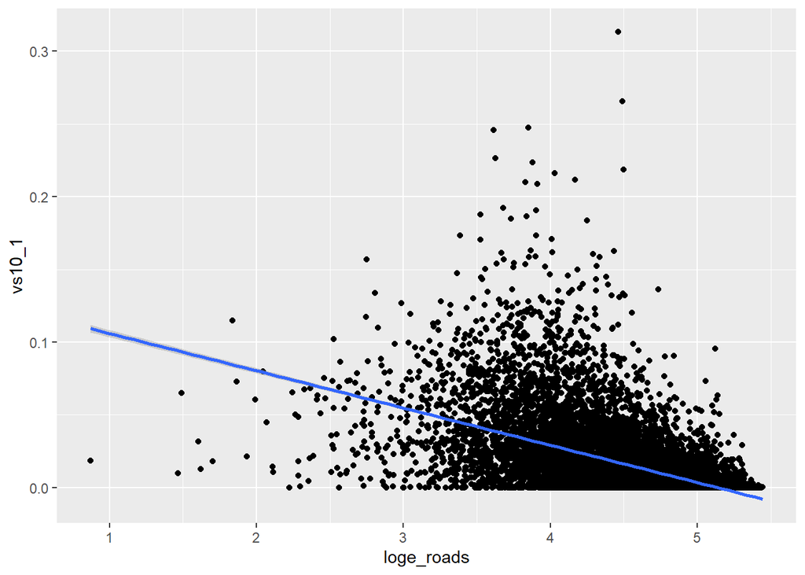

```r
ggplot (reg0, aes(y=vs10_1,x=loge_roads)) + geom_point() + geom_smooth (method="lm")
```

##### 3- linear reg with an added factor (pmv) with a plot

```r
reg10 <- lm(vs10_1 ~ loge_roads + ad_pmv1, cs   )

summary(reg10)
```

```
##
## Call:
## lm(formula = vs10_1 ~ loge_roads + ad_pmv1, data = cs)
##
## Residuals:
##       Min        1Q    Median        3Q       Max
## -0.090503 -0.009657 -0.002781  0.003635  0.296045
##
## Coefficients:
##               Estimate Std. Error t value Pr(>|t|)
## (Intercept)  0.1312698  0.0016434  79.878   <2e-16 ***
## loge_roads  -0.0255586  0.0003541 -72.179   <2e-16 ***
## ad_pmv1      0.0006129  0.0006571   0.933    0.351
## ---
## Signif. codes:  0 '***' 0.001 '**' 0.01 '*' 0.05 '.' 0.1 ' ' 1
##
## Residual standard error: 0.02064 on 12521 degrees of freedom
## Multiple R-squared:  0.2968, Adjusted R-squared:  0.2967
## F-statistic:  2643 on 2 and 12521 DF,  p-value: < 2.2e-16
```

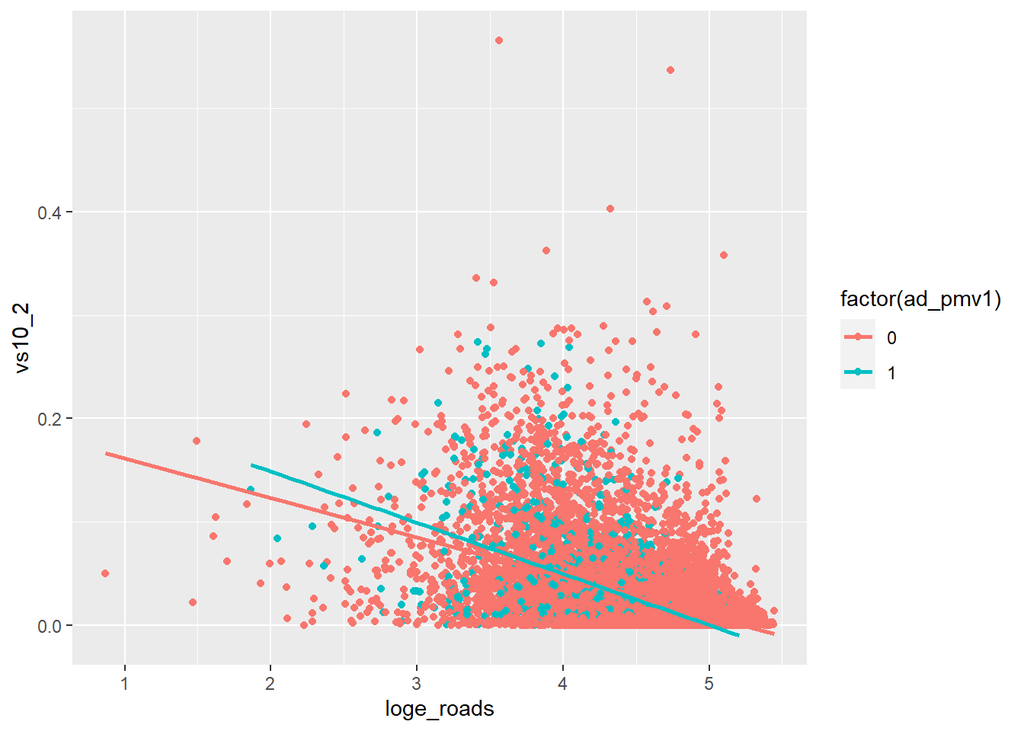

```r
ggplot(cs,aes(y=vs10_2,x=loge_roads,color=factor(ad_pmv1)))+geom_point()+stat_smooth(method="lm",se=FALSE)
```

Here we can see again the same relatioship but with a dummy for the PMV added. This was not significant to the treatment, which makes a lot of sense since PMV doesn’t state anything about roads!

```r
reg11 <- lm(vs10_1 ~ veg10 + ad_pmv1, cs    )

summary(reg11)
```

```
##
## Call:
## lm(formula = vs10_1 ~ veg10 + ad_pmv1, data = cs)
##
## Residuals:
##       Min        1Q    Median        3Q       Max
## -0.047163 -0.004589 -0.001480  0.001058  0.277686
##
## Coefficients:
##               Estimate Std. Error t value Pr(>|t|)
## (Intercept)  0.0434210  0.0003750 115.798  < 2e-16 ***
## veg10       -0.0418788  0.0004612 -90.796  < 2e-16 ***
## ad_pmv1      0.0037423  0.0006041   6.195 6.02e-10 ***
## ---
## Signif. codes:  0 '***' 0.001 '**' 0.01 '*' 0.05 '.' 0.1 ' ' 1
##
## Residual standard error: 0.01907 on 12521 degrees of freedom
## Multiple R-squared:  0.3996, Adjusted R-squared:  0.3995
## F-statistic:  4166 on 2 and 12521 DF,  p-value: < 2.2e-16
```

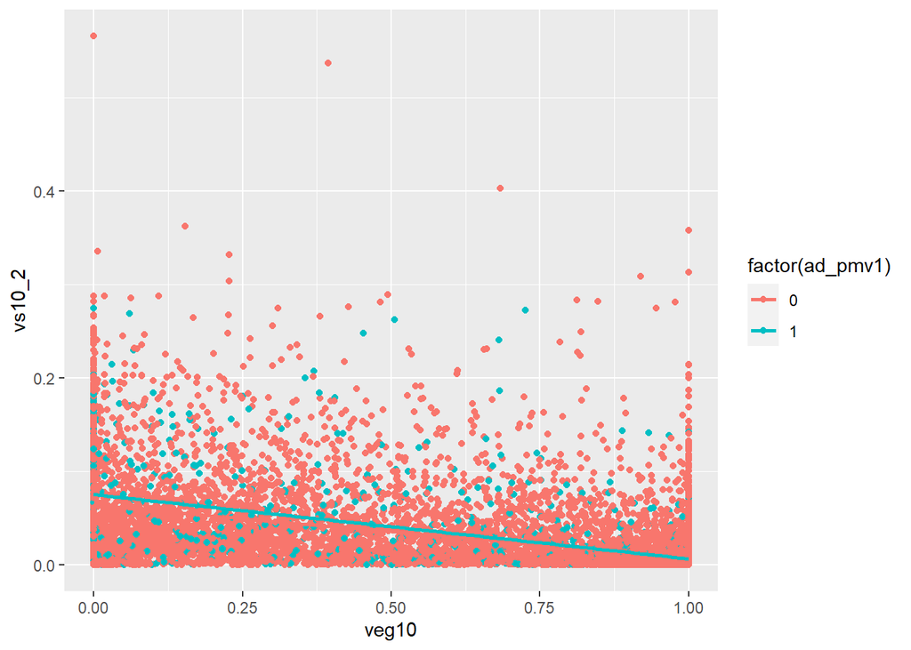

```r
ggplot(cs,aes(y=vs10_2,x=veg10,color=factor(ad_pmv1)))+geom_point()+stat_smooth(method="lm",se=FALSE)
```

On the other hand, when repeating the same test with a different explanatory variable, now the total amount of old growth forests (veg10) things change a little bit: the inclusion of municipalities in the PMV appears to be a significant factor!

```r
reg2 <- lm(vs10_1 ~ veg10   +

             va10_4 +

             ag_slope_1 +loge_roads +

             loge_ports +

             loge_airpo + c_allAMZ  +

             vnl_1, cs)



summary(reg2)
```

```
##
## Call:
## lm(formula = vs10_1 ~ veg10 + va10_4 + ag_slope_1 + loge_roads +
##     loge_ports + loge_airpo + c_allAMZ + vnl_1, data = cs)
##
## Residuals:
##       Min        1Q    Median        3Q       Max
## -0.058478 -0.007208 -0.000833  0.004070  0.277890
##
## Coefficients:
##               Estimate Std. Error t value Pr(>|t|)
## (Intercept)  0.1115901  0.0041904  26.630  < 2e-16 ***
## veg10       -0.0269930  0.0009067 -29.770  < 2e-16 ***
## va10_4       0.0046461  0.0013592   3.418 0.000632 ***
## ag_slope_1  -0.0216550  0.0010320 -20.983  < 2e-16 ***
## loge_roads  -0.0091005  0.0004026 -22.605  < 2e-16 ***
## loge_ports  -0.0100390  0.0006687 -15.013  < 2e-16 ***
## loge_airpo   0.0037066  0.0006676   5.552 2.88e-08 ***
## c_allAMZ    -0.0033551  0.0004210  -7.969 1.74e-15 ***
## vnl_1        0.0076417  0.0005302  14.414  < 2e-16 ***
## ---
## Signif. codes:  0 '***' 0.001 '**' 0.01 '*' 0.05 '.' 0.1 ' ' 1
##
## Residual standard error: 0.01765 on 12515 degrees of freedom
## Multiple R-squared:  0.4859, Adjusted R-squared:  0.4856
## F-statistic:  1479 on 8 and 12515 DF,  p-value: < 2.2e-16
```

When adding variables from different categories, testing a multivariate linear regression aiming at explaining change in vs10_1, the results show a significant role for those variables with a good R square.

### Thanks for joining us :)

# We <3 R!